# Assignment13

Yifei

2018/11/28

1. Title: Glass Identification Database
2. Sources:
   1. Creator: B. German – Central Research Establishment Home Office Forensic Science Service Aldermaston, Reading, Berkshire RG7 4PN
   2. Donor: Vina Spiehler, Ph.D., DABFT Diagnostic Products Corporation (213) 776-0180 (ext 3014)
   3. Date: September, 1987
3. Past Usage: – Rule Induction in Forensic Science – Ian W. Evett and Ernest J. Spiehler – Central Research Establishment Home Office Forensic Science Service Aldermaston, Reading, Berkshire RG7 4PN – Unknown technical note number (sorry, not listed here) – General Results: nearest neighbor held its own with respect to the rule-based system
4. Relevant Information:n Vina conducted a comparison test of her rule-based system, BEAGLE, the nearest-neighbor algorithm, and discriminant analysis. BEAGLE is a product available through VRS Consulting, Inc.; 4676 Admiralty Way, Suite 206; Marina Del Ray, CA 90292 (213) 827-7890 and FAX: -3189. In determining whether the glass was a type of “float” glass or not, the following results were obtained (# incorrect answers):

   ```
        Type of Sample                            Beagle   NN    DA
        Windows that were float processed (87)     10      12    21
        Windows that were not:            (76)     19      16    22
   ```

   The study of classification of types of glass was motivated by criminological investigation. At the scene of the crime, the glass left can be used as evidence…if it is correctly identified!
5. Number of Instances: 214
6. Number of Attributes: 10 (including an Id#) plus the class attribute – all attributes are continuously valued
7. Attribute Information:
8. Id number: 1 to 214
9. RI: refractive index
10. Na: Sodium (unit measurement: weight percent in corresponding oxide, as are attributes 4-10)
11. Mg: Magnesium
12. Al: Aluminum
13. Si: Silicon
14. K: Potassium
15. Ca: Calcium
16. Ba: Barium
17. Fe: Iron
18. Type of glass: (class attribute) – 1 building_windows_float_processed – 2 building_windows_non_float_processed – 3 vehicle_windows_float_processed – 4 vehicle_windows_non_float_processed (none in this database) – 5 containers – 6 tableware – 7 headlamps
19. Missing Attribute Values: None

Summary Statistics: Attribute: Min Max Mean SD Correlation with class 2. RI: 1.5112 1.5339 1.5184 0.0030 -0.1642 3. Na: 10.73 17.38 13.4079 0.8166 0.5030 4. Mg: 0 4.49 2.6845 1.4424 -0.7447 5. Al: 0.29 3.5 1.4449 0.4993 0.5988 6. Si: 69.81 75.41 72.6509 0.7745 0.1515 7. K: 0 6.21 0.4971 0.6522 -0.0100 8. Ca: 5.43 16.19 8.9570 1.4232 0.0007 9. Ba: 0 3.15 0.1750 0.4972 0.5751 10. Fe: 0 0.51 0.0570 0.0974 -0.1879

9. Class Distribution: (out of 214 total instances) – 163 Window glass (building windows and vehicle windows) – 87 float processed  
   – 70 building windows – 17 vehicle windows – 76 non-float processed – 76 building windows – 0 vehicle windows – 51 Non-window glass – 13 containers – 9 tableware – 29 headlamps

```r
#1
glasstb <- read.csv("glass.csv", col.names = c("num","Rl","Na","Mg","Al","Si","K","Ca","Ba","Fe","TypeOfClass"), header = FALSE)
```

```r
#2
#there is no missing data such like NA, and all data are in good shape in either int or double, and seems like normal distributed.
```

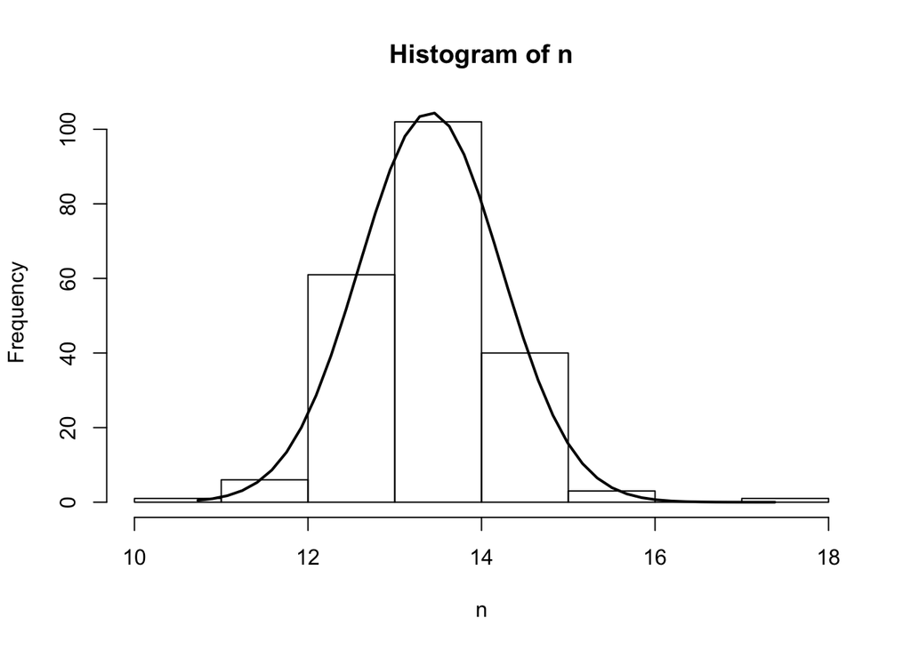

```r
#3 Create a histogram of the Na column and overlay a normal curve; visually determine whether the data is normally distributed. You may use the code from this tutorial. Does the k-NN algorithm require normally distributed data or is it a non-parametric method? Comment on your findings.

n <- glasstb$Na
h <- hist(n)
xfit <- seq(min(n), max(n),length = 40)
yfit <- dnorm(xfit, mean = mean(n), sd = sd(n))
yfit <- yfit * diff(h$mids[1:2]) * length(n)
lines(xfit, yfit, col = "black", lwd = 2)
```

```r
#it is normally distributied.
```

```r
#4 Identify outliers; describe your identification approach and how many and which columns were removed, and why.


outlier_count <- function(i){
  sd <- sd(i)
  mean <- mean(i)
  lower <- mean-3*sd
  upper <- mean+3*sd
  k <- i[(i<lower) | (i>upper)]
  return(length(k))
}

lapply(glasstb, outlier_count)
```

```
## $num
## [1] 0
##
## $Rl
## [1] 3
##
## $Na
## [1] 2
##
## $Mg
## [1] 0
##
## $Al
## [1] 3
##
## $Si
## [1] 6
##
## $K
## [1] 3
##
## $Ca
## [1] 7
##
## $Ba
## [1] 6
##
## $Fe
## [1] 3
##
## $TypeOfClass
## [1] 0
```

```r
#this produces how many outliers in each
```

```r
# remove the outlier
library(dplyr)
outlier_remove <- function(table){
   for(i in 1:ncol(table)){
      col1_sd <- sd(table[,i])
  col1_mean <- mean(table[,i])
    output<- table %>%
      filter(col1_mean-3*col1_sd<table[,i]&table[,i]< col1_mean+3*col1_sd)
}
  return(output)
}
```

```r
#5 After removing the ID column (column 1), normalize the first two columns in the data set using min-max normalization.
#remove ID column
glasstb <- glasstb[,-1]

#normalize the first two column using min-max normalization


normalize <- function(x) {
  return ((x - min(x)) / (max(x) - min(x)))
}

Rl_Na_n <- as.data.frame(lapply(glasstb[1:2], normalize))

summary(Rl_Na_n)
```

```
##        Rl               Na
##  Min.   :0.0000   Min.   :0.0000
##  1st Qu.:0.2358   1st Qu.:0.3274
##  Median :0.2867   Median :0.3865
##  Mean   :0.3167   Mean   :0.4027
##  3rd Qu.:0.3515   3rd Qu.:0.4654
##  Max.   :1.0000   Max.   :1.0000
```

```r
#6 Normalize the remaining columns, except the last one, using z-score standardization. The last column is the glass type and so it is excluded.

znormalize <- function(x) {
  return ((x - mean(x)) / sd(x))
}

others.n <- as.data.frame(lapply(glasstb[3:9], znormalize))
summary(others.n)
```

```
##        Mg                Al                Si                K
##  Min.   :-1.8611   Min.   :-2.3132   Min.   :-3.6679   Min.   :-0.76213
##  1st Qu.:-0.3948   1st Qu.:-0.5106   1st Qu.:-0.4789   1st Qu.:-0.57430
##  Median : 0.5515   Median :-0.1701   Median : 0.1795   Median : 0.08884
##  Mean   : 0.0000   Mean   : 0.0000   Mean   : 0.0000   Mean   : 0.00000
##  3rd Qu.: 0.6347   3rd Qu.: 0.3707   3rd Qu.: 0.5636   3rd Qu.: 0.17318
##  Max.   : 1.2517   Max.   : 4.1162   Max.   : 3.5622   Max.   : 8.75961
##        Ca                Ba                Fe
##  Min.   :-2.4783   Min.   :-0.3521   Min.   :-0.5851
##  1st Qu.:-0.5038   1st Qu.:-0.3521   1st Qu.:-0.5851
##  Median :-0.2508   Median :-0.3521   Median :-0.5851
##  Mean   : 0.0000   Mean   : 0.0000   Mean   : 0.0000
##  3rd Qu.: 0.1515   3rd Qu.:-0.3521   3rd Qu.: 0.4412
##  Max.   : 5.0824   Max.   : 5.9832   Max.   : 4.6490
```

```r
n_total <- cbind.data.frame(Rl_Na_n, others.n)
n_total <- cbind.data.frame(n_total, glasstb[10])
```

```r
#7 The data set is sorted, so creating a validation data set requires random selection of elements. Create a stratified sample where you randomly select 50% of each of the cases for each glass type to be part of the validation data set. The remaining cases will form the training data set.

rownum <- nrow(glasstb)
validationsetindex <- sample(1:rownum, rownum*0.5, replace = FALSE)
validation_set <- n_total[validationsetindex,]
train_set <-n_total[-validationsetindex,]
train_set_label <- n_total[-validationsetindex, 10]
validation_set_label <- n_total[validationsetindex, 10]
```

```r
#8 Implement the k-NN algorithm in R (do not use an implementation of k-NN from a package) and use your algorithm with a k=10 to predict the glass type for the following two cases:
# RI = 1.51621 | 12.53 | 3.48 | 1.39 | 73.39 | 0.60 | 8.55 | 0.00 | Fe = 0.05
# RI = 1.5098 | 12.77 | 1.85 | 1.81 | 72.69 | 0.59 | 10.01 | 0.00 | Fe = 0.01
#calculating distance first
calculateDist <- function(a,b){
  d = 0
  for(i in c(1:(length(a)-1) )){
    d = d + (a[[i]]-b[[i]])^2
  }
  d = sqrt(d)
  return(d)
}

#prediction function
knn_predict <- function(test, train, k_val){
  pred1 <- rep(0, nrow(test))
  #loop the test data
  for(i in c(1:nrow(test))){
    #initial vector variable with empty, and good bad variable with 0 value
  e_dis = c()
  e_int = c()

  for(j in c(1:nrow(train))){
    #add distance between train set and test set
    e_dis <- c(e_dis, calculateDist(test[i,],train[j,]))
    e_int <- c(e_int, as.integer(train[j,][[10]]))
  }
  #e is a data frame contain the type and the distance
  #we put them in order select the first k smallest distance data
  e <- data.frame(e_int, e_dis)
  e <- e[order(e$e_dis),]
  e <- e[1: k_val,]

  #show the answer
 e_table <- table(e[1])
  answer <- names(which.max(e_table))
  #paste them into answer storage
  pred1[i] <- answer
  }

  return(pred1)

}

#first I need to  fill the data with a number, no matter that is, because when we predict we need the dimension to be the same

pr <- knn_predict(validation_set, train_set,10)
pr
```

```
##   [1] "7" "2" "7" "7" "2" "7" "1" "2" "2" "2" "7" "1" "2" "7" "1" "1" "1"
##  [18] "1" "1" "1" "1" "1" "1" "1" "1" "2" "2" "2" "7" "1" "2" "2" "7" "2"
##  [35] "2" "2" "7" "2" "2" "1" "7" "2" "2" "7" "1" "2" "1" "2" "1" "7" "2"
##  [52] "2" "2" "2" "1" "7" "2" "1" "1" "2" "2" "1" "2" "1" "7" "1" "1" "2"
##  [69] "2" "2" "1" "1" "1" "1" "1" "2" "2" "2" "2" "2" "2" "7" "2" "3" "2"
##  [86] "2" "1" "2" "2" "2" "2" "1" "2" "7" "2" "2" "1" "7" "1" "1" "2" "7"
## [103] "1" "2" "2" "1" "1"
```